# Equilibrium in CHNOSZ

This document deﬁnes the concepts, explains the organization of functions, and provides examples of calculating equilibrium in CHNOSZ. It also highlights some applications of the methods (i.e. to reproduce published diagrams) and includes an Appendix on details of the equilibration calculations.

```r
library(CHNOSZ)
data(thermo)
```

```
## data(thermo): attached environment "CHNOSZ"
```

```
## thermo$obigt: 1911 aqueous, 3588 total species
```

```r
## thermo$obigt: 1911 aqueous, 3588 total species
basis("CHNOS")
```

```
##     C H N O S ispecies logact state
## CO2 1 0 0 2 0     1576     -3    aq
## H2O 0 2 0 1 0        1      0   liq
## NH3 0 3 1 0 0       66     -4    aq
## H2S 0 2 0 0 1       67     -7    aq
## O2  0 0 0 2 0     3316    -80   gas
```

```r
species(aminoacids(""))[1:5, ]
```

```
##   CO2 H2O NH3 H2S    O2 ispecies logact state          name
## 1   3   2   1   0  -3.0     1611     -3    aq       alanine
## 2   3   1   1   1  -2.5     1618     -3    aq      cysteine
## 3   4   2   1   0  -3.0     1616     -3    aq aspartic acid
## 4   5   3   1   0  -4.5     1621     -3    aq glutamic acid
## 5   9   4   1   0 -10.0     1633     -3    aq phenylalanine
```

Code for making the diagrams. Function names refer to the subﬁgure labels.

```r
res <- 200
aa <- aminoacids()

aaA <- function() {
a <- affinity(O2=c(-90, -70, res), H2O=c(-20, 10, res))
diagram(a, balance=1, names=aa)
}

aaB <- function() {
a <- affinity(O2=c(-90, -70, 80), H2O=c(-20, 10, 80))
e <- equilibrate(a, balance=1)
diagram(e, names=aa)
}

aaC <- function() {
a <- affinity(O2=c(-71, -66, res), H2O=c(-8, 4, res))
diagram(a, balance="CO2", names=aa)
}

aaD <- function() {
a <- affinity(O2=c(-71, -66, 80), H2O=c(-8, 4, 80))
e <- equilibrate(a, balance="CO2")
diagram(e, names=aa)
}

aaE <- function() {
basis("O2", -66)
a <- affinity(H2O=c(-8, 4))
e <- equilibrate(a, balance="CO2")
diagram(e, ylim=c(-5, -1), names=aa)
}

aaF <- function() {
species(1:20, -4)
a <- affinity(H2O=c(-8, 4))
e <- equilibrate(a, balance="CO2")
diagram(e, ylim=c(-5, -1), names=aa)

}
```

```r
AA <- aminoacids("")
names(AA) <- aa
AA
```

```
##               A               C               D               E               F
##       "alanine"      "cysteine" "aspartic acid" "glutamic acid" "phenylalanine"
##               G               H               I               K               L
##       "glycine"     "histidine"    "isoleucine"        "lysine"       "leucine"
##               M               N               P               Q               R
##    "methionine"    "asparagine"       "proline"     "glutamine"      "arginine"
##               S               T               V               W               Y
##        "serine"     "threonine"        "valine"    "tryptophan"      "tyrosine"
```

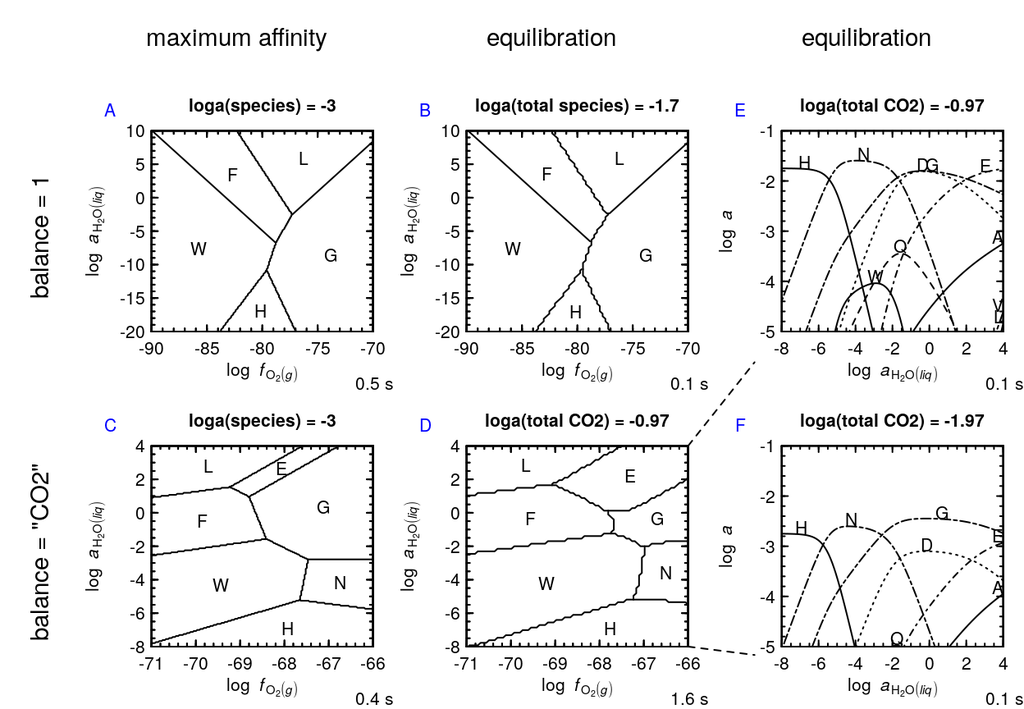

Comments on the plots: • The equal-activity lines in Figures A and B are identical. For balance = 1, the maximum afﬁnity method and the equilibration method should produce the same predominance diagrams. (More precisely, because balance = 1, the conditions of equal activity of any species of interest are independent of the actual value of that activity.)

Figures C and D are different. For balance 6= 1, the maximum afﬁnity method and the equilibration method will generally produce difference predominance diagrams. (Because balance 6= 1, the condi- tions of equal activity of any species of interest depend on the actual value of that activity.) • Both Figures E and F are constructed using the equilibration method, to calculate activities of species as a function of log aH2O at log fO2 = −66. Figure E shows the results for the default settings (aCO2 is the sum of activities present in all species, taken from initial species activity of 10−3) and the crossing lines indicating equal activities are identical to the positions in Figure D at log fO2 = −66. • Figure F shows the results for a lower total activity of CO2. Consequently, the activities of the predom- inant species decrease from ca. 10−2 in Figure E to ca. 10−3 in Figure F. Also, the stability region of the smaller glycine has grown at the expense of the neighboring bigger amino acids, so that the crossing lines indicating equal activities in Figure F are closer to those shown in Figure C at log fO2 = −66. • In other words, a lower equal-activity value causes the stability region of the species with the smaller balance coefﬁcient to invade that of the species with the larger balance coefﬁcient. • Figures A, B, C, and D are all equal activity diagrams, but have different constraints on the activities: – Maximum afﬁnity method (Figures A, C): Equal activities of species set to a constant value. – Equilibration method (Figures B, D): Equal activities of species determined by overall speciation of the system.

## 3.2 Proteins

Basis species: CO2, H2O, NH3, H2S, O2, H+. Species of interest: 6 proteins from the set of archaeal and bacterial surface layer proteins considered by Dick (2008).

```r
basis("CHNOS+")
```

```
##     C H N O S Z ispecies logact state
## CO2 1 0 0 2 0 0     1576     -3    aq
## H2O 0 2 0 1 0 0        1      0   liq
## NH3 0 3 1 0 0 0       66     -4    aq
## H2S 0 2 0 0 1 0       67     -7    aq
## O2  0 0 0 2 0 0     3316    -80   gas
## H+  0 1 0 0 0 1        3     -7    aq
```

```r
organisms <- c("METJA", "HALJP", "METVO", "ACEKI", "GEOSE", "BACLI")
proteins <- c(rep("CSG", 3), rep("SLAP", 3))
species(proteins, organisms)
```

```
##    CO2  H2O  NH3 H2S    O2 H+ ispecies logact state       name
## 1 2555 1042  640  14 -2644  0     3589     -3    aq  CSG_METJA
## 2 3669 1367  971   0 -3608  0     3590     -3    aq  CSG_HALJP
## 3 2575 1070  645  11 -2668  0     3591     -3    aq  CSG_METVO
## 4 3584 1431  926   4 -3730  0     3592     -3    aq SLAP_ACEKI
## 5 5676 2320 1489   3 -5904  0     3593     -3    aq SLAP_GEOSE
## 6 3977 1594 1068   2 -4131  0     3594     -3    aq SLAP_BACLI
```

```r
prA <- function() {
a <- affinity(O2=c(-90, -70, 80), H2O=c(-20, 0, 80))
e <- equilibrate(a, balance="length", loga.balance=0)
diagram(e, names=organisms)
}

prB <- function() {
a <- affinity(O2=c(-90, -70))
e <- equilibrate(a, balance="length", loga.balance=0)
diagram(e, names=organisms, ylim=c(-5, -1))
}

prC <- function() {
a <- affinity(O2=c(-90, -70, res), H2O=c(-20, 0, res))
e <- equilibrate(a, normalize=TRUE, loga.balance=0)
diagram(e, names=organisms)
}

prD <- function() {
a <- affinity(O2=c(-90, -70))
e <- equilibrate(a, normalize=TRUE, loga.balance=0)
diagram(e, names=organisms, ylim=c(-5, -1))

}

prE <- function() {
a <- affinity(O2=c(-90, -70, res), H2O=c(-20, 0, res))
e <- equilibrate(a, as.residue=TRUE, loga.balance=0)
diagram(e, names=organisms)
}

prF <- function() {
a <- affinity(O2=c(-90, -70))
e <- equilibrate(a, as.residue=TRUE, loga.balance=0)
diagram(e, names=organisms, ylim=c(-3, 1))
}
```

The plots follow. As before, the code used to layout the ﬁgure and label the plots is not shown in the PDF.

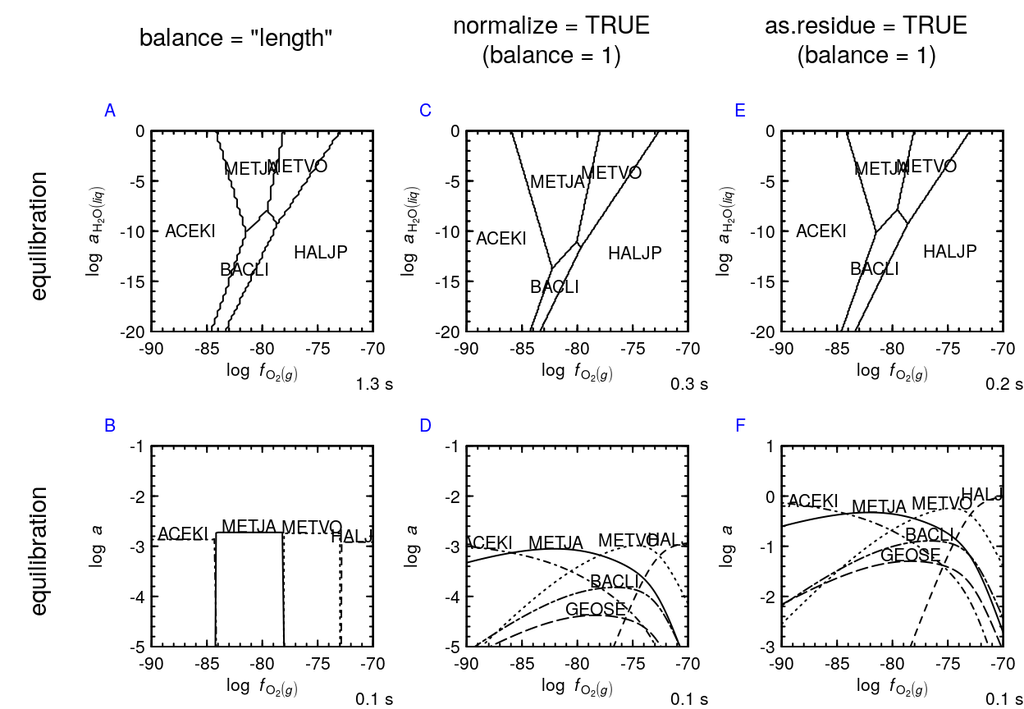

```r
layout(t(matrix(1:3)))
species(1:6, -111)
a <- affinity(O2=c(-90, -70, res), H2O=c(-20, 0, res))
d1 <- diagram(a, balance="length", names=organisms, main='balance = "length"')
d2 <- diagram(a, normalize=TRUE, names=organisms, main="normalize = TRUE")
d3 <- diagram(a, as.residue=TRUE, names=organisms, main="as.residue = TRUE")
```

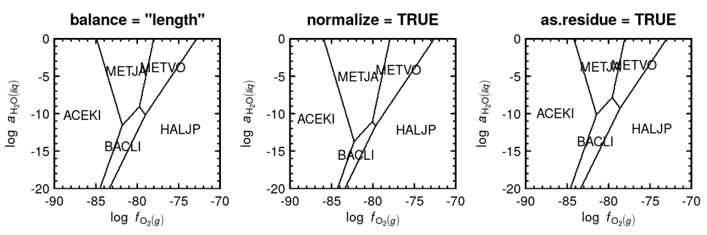

```r
stopifnot(!identical(d1$predominant, dA$predominant))
stopifnot(identical(d2$predominant, dC$predominant))
stopifnot(identical(d3$predominant, dE$predominant))
```

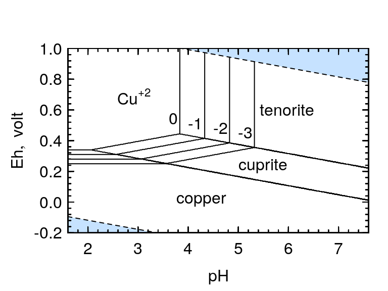

```r
basis(c("Cu+2", "H2O", "H+", "e-"))
species(c("Cu+2", "copper", "cuprite", "tenorite"))
for(loga in c(-1, 0, -2, -3)) {
  species("Cu+2", loga)
  a <- affinity(pH=c(1.6, 7.6, 400), Eh=c(-0.2, 1, 400))
  if(loga==-1) d <- diagram(a)
  else d <- diagram(a, add=TRUE, names=NULL)
  iCu <- which(d$predominant == 1, arr.ind=TRUE)
  text(a$vals[[1]][max(iCu[, 1])] - 0.03, a$vals[[2]][min(iCu[, 2])] + 0.2, adj=1, loga)
}
water.lines(d)
```

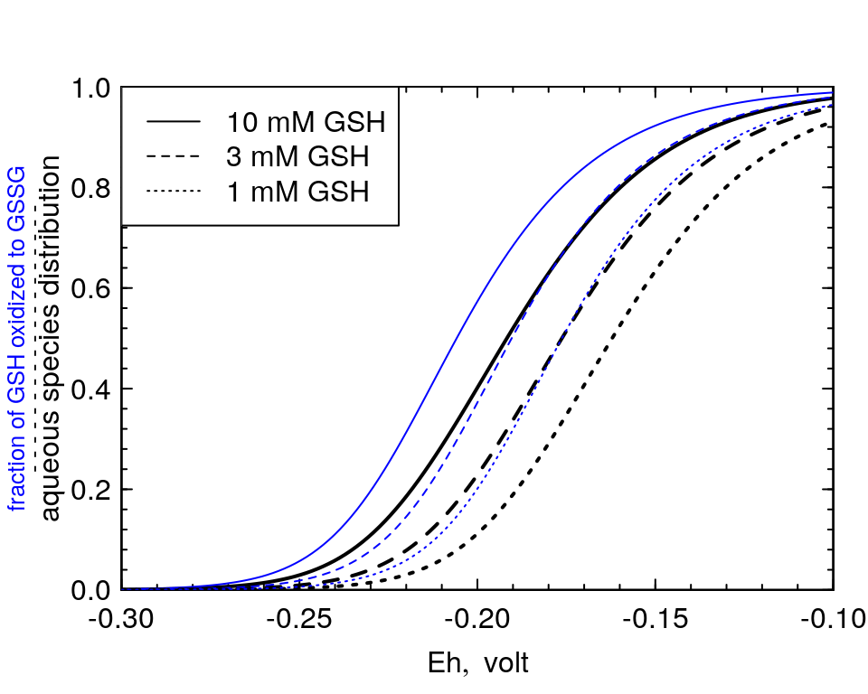

```r
basis(c("GSH", "NH3", "H2S", "H2O", "H+", "e-"))
basis("pH", 7)
species(c("GSH", "GSSG"))
a <- affinity(Eh=c(-0.3, -0.1))
# initial millimoles of GSH
mM <- c(10, 3, 1)
M <- mM * 1e-3
for(i in 1:3) {
  e <- equilibrate(a, loga.balance=log10(M[i]))
  diagram(e, alpha=TRUE, lty=c(0, i), add = i!=1, legend.x=NULL, ylim=c(0, 1), yline=1.6, lwd=2, ylab="aqueous species distribution")
  fGSH <- 1 - (10^e$loga.equil[[1]] / M[i])
  lines(e$vals[[1]], fGSH, col="blue", lty=i)
}
mtext(side=2, "fraction of GSH oxidized to GSSG", las=0, line=2.6, col="blue", cex=0.8)
mtext(side=2, "- - - - - - - - - - - - - - - - - - -", las=0, line=2.1, cex=0.8)
legend("topleft", lty=1:3, legend=paste(mM, "mM GSH"))
```

## 4.3 Mosaic diagrams

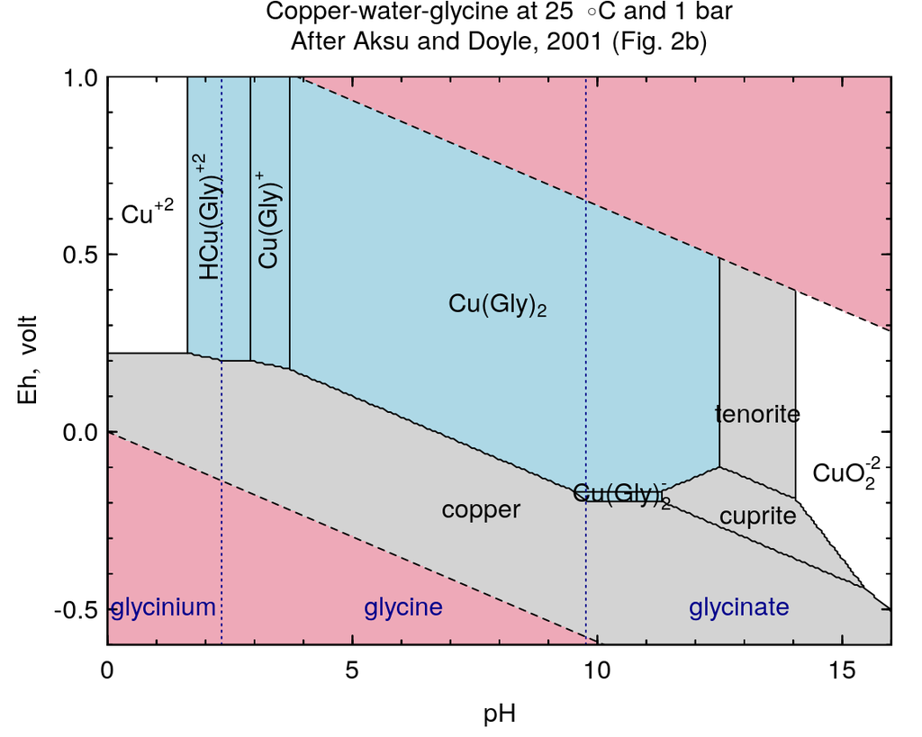

```r
demo("copper", ask=FALSE)
```

```r
data(thermo)
```

```
## thermo$obigt: 1911 aqueous, 3588 total species
```

```r
mod.obigt("[Met]", G=-35245, H=-59310)
```

```
## mod.obigt: updated [Met](aq)
```

```
## [1] 1867
```

```r
basis("CHNOS+")
```

```
##     C H N O S Z ispecies logact state
## CO2 1 0 0 2 0 0     1576     -3    aq
## H2O 0 2 0 1 0 0        1      0   liq
## NH3 0 3 1 0 0 0       66     -4    aq
## H2S 0 2 0 0 1 0       67     -7    aq
## O2  0 0 0 2 0 0     3316    -80   gas
## H+  0 1 0 0 0 1        3     -7    aq
```

```r
species("CSG",c("METVO", "METJA"))
```

```
##    CO2  H2O NH3 H2S    O2 H+ ispecies logact state      name
## 1 2575 1070 645  11 -2668  0     3589     -3    aq CSG_METVO
## 2 2555 1042 640  14 -2644  0     3590     -3    aq CSG_METJA
```

```r
a <- affinity()
```

```
## energy.args: temperature is 25 C
```

```
## energy.args: pressure is Psat
```

```
## subcrt: 8 species at 298.15 K and 1 bar (wet)
```

```
## subcrt: 18 species at 298.15 K and 1 bar (wet)
```

```r
a$values
```

[output not shown]

```r
e <- equilibrate(a)
```

```
## balance: from protein length
```

```
## equilibrate: n.balance is 553 530
```

```
## equilibrate: loga.balance is 0.0346284566253204
```

```
## equilibrate: using reaction method
```

```r
e$loga.equil
```

[output not shown]

```r
protein.basis(species()$name, normalize=TRUE)
```

```
## subcrt: 18 species at 298.15 K and 1 bar (wet)
```

```
##       CO2  H2O  NH3    H2S    O2     H+
## [1,] 4.66 1.93 1.17 0.0199 -4.82 -0.101
## [2,] 4.82 1.97 1.21 0.0264 -4.99 -0.105
```

```r
protein <- pinfo(c("CSG_METVO", "CSG_METJA"))
basis("CHNOS+")
swap.basis("O2", "H2")
```

```
## subcrt: 6 species at 298.15 K and 1 bar (wet)
## subcrt: 6 species at 298.15 K and 1 bar (wet)
```

```r
protein.equil(protein, loga.protein=-3)
```

```
## protein.equil: temperature from argument is 25 degrees C
```

```
## protein.equil: pH from thermo$basis is 7
```

```
## checkGHS: G of [Met] aq (1867) differs by -132 cal mol-1 from tabulated value
```

```
## protein.equil: [Met] is from reference DLH06 [S15]
```

```
## protein.equil [1]: first protein is CSG_METVO with length 553
```

```
## protein.equil [1]: reaction to form nonionized protein from basis species has G0(cal/mol) of -47580000
```

```
## protein.equil [1]: ionization reaction of protein has G0(cal/mol) of -95830
```

```
## protein.equil [1]: per residue, reaction to form ionized protein from basis species has G0/RT of -145.5
```

```
## protein.equil [1]: per residue, logQstar is 63.01
```

```
## protein.equil [1]: per residue, Astar/RT = -G0/RT - 2.303logQstar is 0.4359
```

```
## check it!       per residue, Astar/RT calculated using affinity() is 0.4359
```

```
## protein.equil [all]: lengths of all proteins are 553 530
```

```
## protein.equil [all]: Astar/RT of all residue equivalents are 0.4359 1.365
```

```
## protein.equil [all]: sum of exp(Astar/RT) of all residue equivalents is 5.462
```

```
## protein.equil [all]: equilibrium degrees of formation (alphas) of residue equivalents are 0.2831 0.7169
```

```
## check it!     alphas of residue equivalents from equilibrate() are 0.2831 0.7169
```

```
## protein.equil [all]: for activity of proteins equal to 10^-3, total activity of residues is 10^0.03463
```

```
## protein.equil [all]: log10 equilibrium activities of residue equivalents are -0.5134 -0.1099
```

```
## protein.equil [all]: log10 equilibrium activities of proteins are -3.256 -2.834
```

```
## check it!    log10 eq'm activities of proteins from equilibrate() are -3.256 -2.834
```

## D.2 Visualizing the effects of normalization

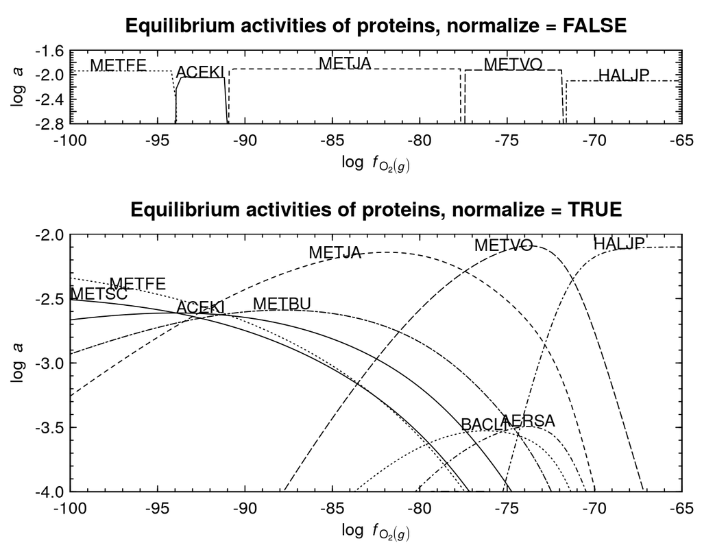

```r
organisms <- c("METSC", "METJA", "METFE", "HALJP",  "METVO", "METBU", "ACEKI", "GEOSE", "BACLI", "AERSA")
proteins <- c(rep("CSG", 6), rep("SLAP", 4))
basis("CHNOS+")
species(proteins, organisms)
a <- affinity(O2=c(-100, -65))
layout(matrix(1:2), heights=c(1, 2))
e <- equilibrate(a)
diagram(e, ylim=c(-2.8, -1.6), names=organisms)
water.lines(e)
title(main="Equilibrium activities of proteins, normalize = FALSE")
e <- equilibrate(a, normalize=TRUE)
diagram(e, ylim=c(-4, -2), names=organisms)
water.lines(e)
title(main="Equilibrium activities of proteins, normalize = TRUE")
```

Although it is well below the stability limit of H2O (vertical dashed line), there is an interesting con- vergence of the activities of some proteins at low log fO2 , due most likely to compositional similarity of the amino acid sequences. The reaction-matrix approach can also be applied to systems having conservation coefﬁcients that differ from unity, such as many mineral and inorganic systems, where the immobile component has different molar coefﬁcients in the formulas. For example, consider a system like one described by Seewald (1996).

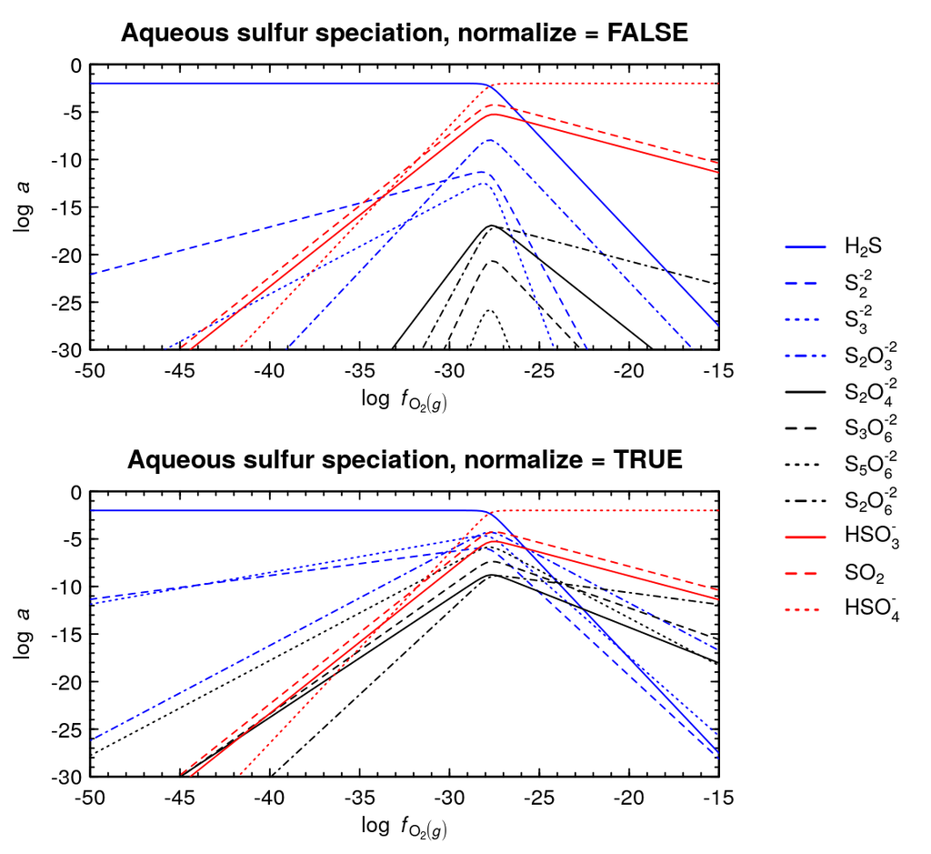

```r
basis("CHNOS+")
basis("pH", 5)
species(c("H2S", "S2-2", "S3-2", "S2O3-2", "S2O4-2",  "S3O6-2", "S5O6-2", "S2O6-2", "HSO3-", "SO2", "HSO4-"))
a <- affinity(O2=c(-50, -15), T=325, P=350)
layout(matrix(c(1, 2, 3, 3), nrow=2), widths=c(4, 1))
col <- rep(c("blue", "black", "red"), each=4)
lty <- 1:4
for(normalize in c(FALSE, TRUE)) {
  e <- equilibrate(a, loga.balance=-2, normalize=normalize)
  diagram(e, ylim=c(-30, 0), legend.x=NULL, col=col, lty=lty)
  water.lines(e)
  title(main=paste("Aqueous sulfur speciation, normalize =", normalize))
}
par(mar=c(0, 0, 0, 0))
plot.new()
leg <- lapply(species()$name, expr.species)
legend("center", lty=lty, col=col, lwd=1.5, bty="n", legend=as.expression(leg), y.intersp=1.3)
```

Cox JD, Wagman DD, Medvedev VA, editors. 1989. *CODATA Key Values for Thermodynamics*. New York: Hemisphere Publishing Corporation. Available at http://www.worldcat.org/oclc/18559968.

Dick JM. 2008. Calculation of the relative metastabilities of proteins using the CHNOSZ software package. *Geochemical Transactions* **9**: 10. doi: 10.1186/1467-4866-9-10

Holland TJB, Powell R. 2011. An improved and extended internally consistent thermodynamic dataset for phases of petrological interest, involving a new equation of state for solids. *Journal of Metamorphic Geology* **29**(3): 333–383. doi: 10.1111/j.1525-1314.2010.00923.x

Johnson JW, Oelkers EH, Helgeson HC. 1992. SUPCRT92: A software package for calculating the standard molal thermodynamic properties of minerals, gases, aqueous species, and reactions from 1 to 5000 bar and 0 to 1000°C. *Computers & Geosciences* **18**(7): 899–947. doi: 10.1016/0098-3004(92)90029-Q

Seewald JS. 1996. Mineral redox buffers and the stability of organic compounds under hydrothermal conditions. *Materials Research Society Symposium Proceedings* **432**: 317–331. doi: 10.1557/PROC-432-317

Tanger JC IV, Helgeson HC. 1988. Calculation of the thermodynamic and transport properties of aqueous species at high pressures and temperatures: Revised equations of state for the standard partial molal properties of ions and electrolytes. *American Journal of Science* **288**(1): 19–98. doi: 10.2475/ajs.288.1.19

Wagner W, Pruß A. 2002. The IAPWS formulation 1995 for the thermodynamic properties of ordinary water substance for general and scientific use. *Journal of Physical and Chemical Reference Data* **31**(2): 387–535. doi: 10.1063/1.1461829